# Homework 3

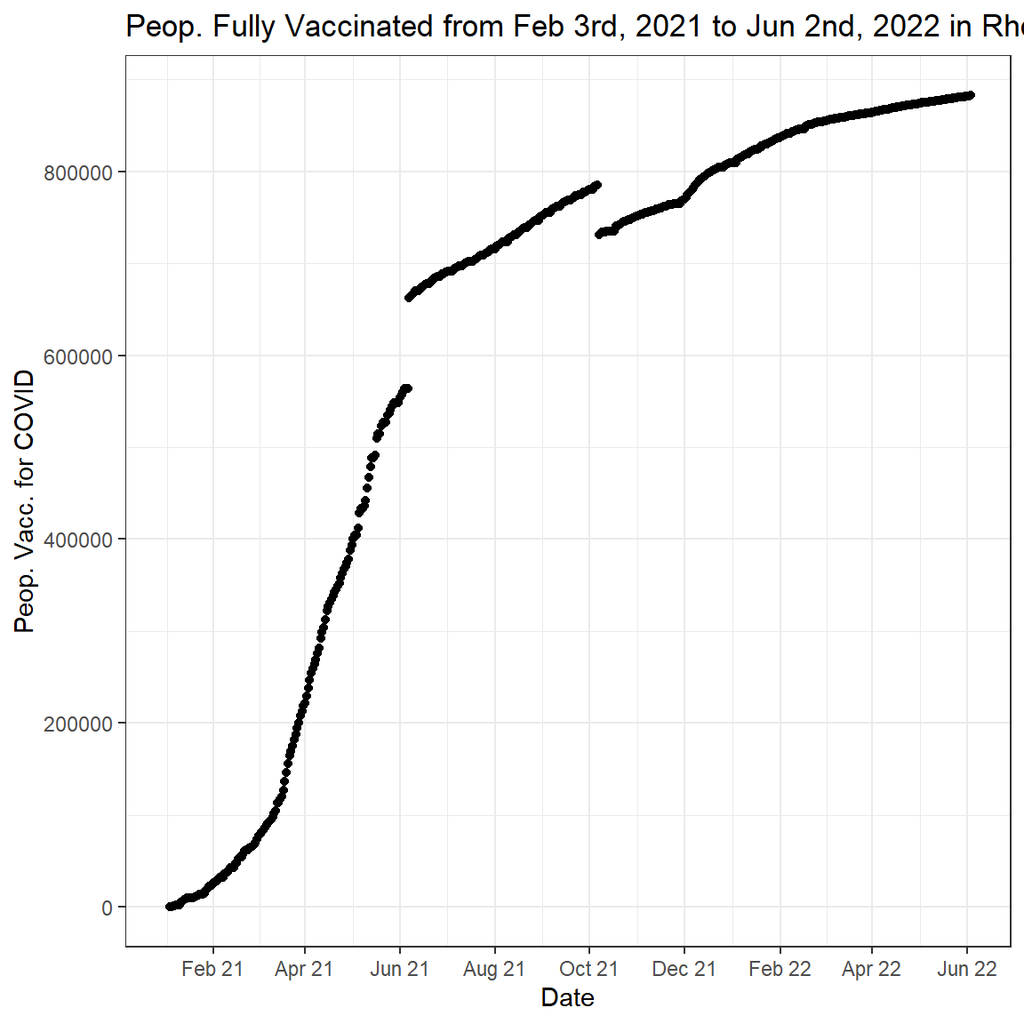

```r
#changing from scientific notation to regular numbers
options(scipen=10000)

#plotting total people vaccinated from Feburary 3rd, 2021 to June 2nd, 2022 in Rhode Island
covid.rhode.island.vacc.plot <- ggplot(data = covid.rhode.island, aes(x = date_col, y = People_Fully_Vaccinated)) +
  geom_point(na.rm=TRUE) +
  ggtitle("Peop. Fully Vaccinated from Feb 3rd, 2021 to Jun 2nd, 2022 in Rhode Island") +
  xlab("Date")+
  ylab("Peop. Vacc. for COVID") +
  (scale_x_date(breaks = date_breaks("2 months"),
                labels = date_format("%b %y"))) +
  scale_y_continuous(breaks = seq(0, 900000, 200000)) +
  theme_bw()
covid.rhode.island.vacc.plot
```

###All Three Plots Together:

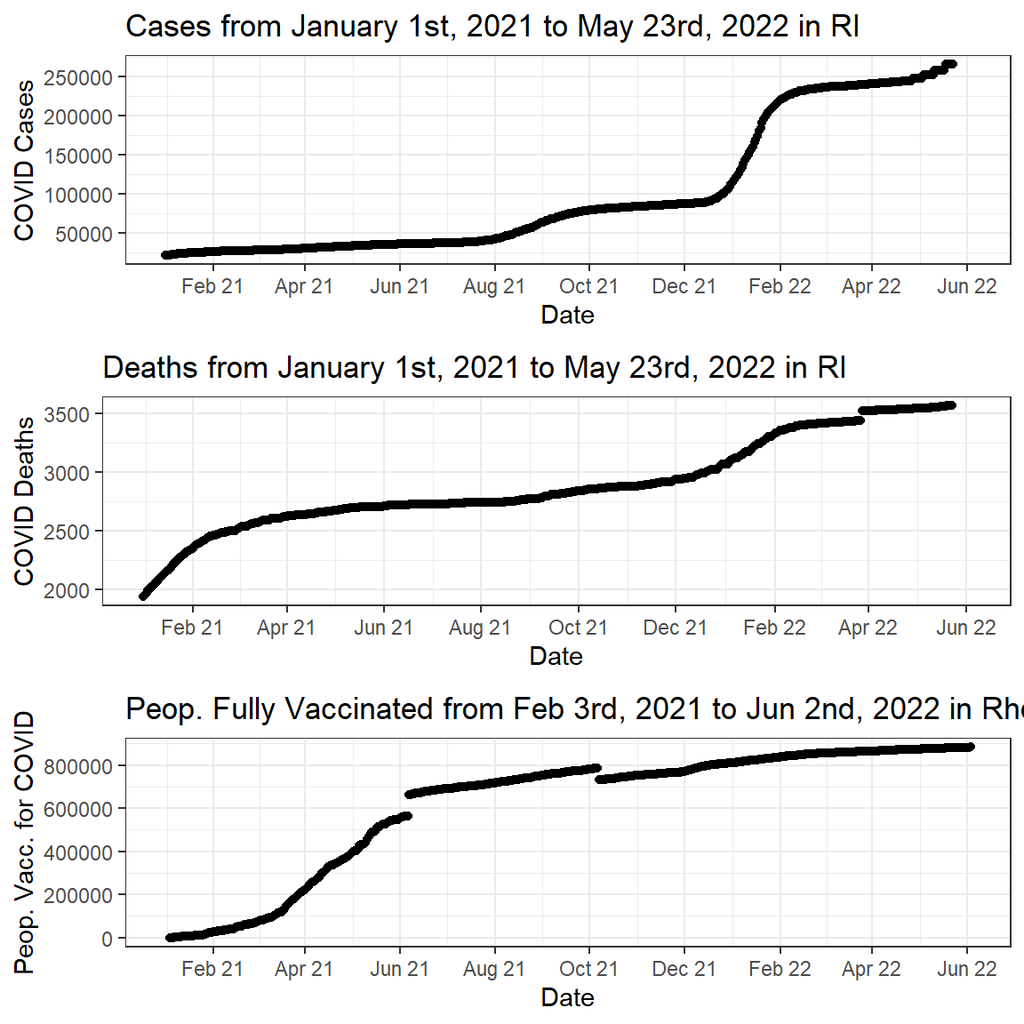

```r
#arranging plots that show cases, deaths, and vaccinations next to each other for Rhode Island
require(gridExtra)
grid.arrange(covid.rhode.island.cases.plot, covid.rhode.island.deaths.plot, covid.rhode.island.vacc.plot, heights=c(1,1,1))
```

4. Do you see any interesting change in the trajectories of the corresponding time series for the number of cases and deaths taking place with vaccinations? Produce **meaningful** summaries that enable you to quantify this change (e.g., average number of new cases in windows of 90 days before vs 90 days after vaccination started). One or two summary measures is good. Make either a table or a figure to display your findings and **comment on them**.

```r
#Finding the average number of new deaths in January, February, and March 2021 (beginning affect of vaccines) vs April, May, and June 2021 (bigger affect of vaccines) vs July, August, and September 2021 (much bigger affect of vaccines).

#filtering California to include only deaths and people fully vaccinated for Jan, Feb, and Mar 2021
covid.california.JFM <- covid.california %>%
  filter(ymd(20210101) <= date_col & date_col <= ymd(20210331)) %>%
  select(Province_State, date_col, total_deaths, People_Fully_Vaccinated)


#filtering Florida to include only deaths and people fully vaccinated for Jan, Feb, and Mar 2021
covid.florida.JFM <- covid.florida %>%
  filter(ymd(20210101) <= date_col & date_col <= ymd(20210331)) %>%
  select(Province_State, date_col, total_deaths, People_Fully_Vaccinated)


#filtering New York to include only deaths and people fully vaccinated for Jan, Feb, and Mar 2021
covid.new.york.JFM <- covid.new.york %>%
  filter(ymd(20210101) <= date_col & date_col <= ymd(20210331)) %>%
  select(Province_State, date_col, total_deaths, People_Fully_Vaccinated)


#filtering Hawaii to include only deaths and people fully vaccinated for Jan, Feb, and Mar 2021
covid.hawaii.JFM <- covid.hawaii %>%
  filter(ymd(20210101) <= date_col & date_col <= ymd(20210331)) %>%
  select(Province_State, date_col, total_deaths, People_Fully_Vaccinated)


#filtering Oregon to include only deaths and people fully vaccinated for Jan, Feb, and Mar 2021
covid.oregon.JFM <- covid.oregon %>%
  filter(ymd(20210101) <= date_col & date_col <= ymd(20210331)) %>%
  select(Province_State, date_col, total_deaths, People_Fully_Vaccinated)


#filtering Rhode Island to include only deaths and people fully vaccinated for Jan, Feb, and Mar 2021
covid.rhode.island.JFM <- covid.rhode.island %>%
  filter(ymd(20210101) <= date_col & date_col <= ymd(20210331)) %>%
  select(Province_State, date_col, total_deaths, People_Fully_Vaccinated)


#finding means of deaths and people fully vaccinated for Jan, Feb, and Mar 2021

mean.covid.california.deaths.JFM <- mean(covid.california.JFM$total_deaths, na.rm = TRUE)
mean.covid.california.vacc.JFM <- mean(covid.california.JFM$People_Fully_Vaccinated, na.rm = TRUE)

mean.covid.florida.deaths.JFM <- mean(covid.florida.JFM$total_deaths, na.rm = TRUE)
mean.covid.florida.vacc.JFM <- mean(covid.florida.JFM$People_Fully_Vaccinated, na.rm = TRUE)

mean.covid.new.york.deaths.JFM <- mean(covid.new.york.JFM$total_deaths, na.rm = TRUE)
mean.covid.new.york.vacc.JFM <- mean(covid.new.york.JFM$People_Fully_Vaccinated, na.rm = TRUE)

mean.covid.hawaii.deaths.JFM <- mean(covid.hawaii.JFM$total_deaths, na.rm = TRUE)
mean.covid.hawaii.vacc.JFM <- mean(covid.hawaii.JFM$People_Fully_Vaccinated, na.rm = TRUE)

mean.covid.oregon.deaths.JFM <- mean(covid.oregon.JFM$total_deaths, na.rm = TRUE)
mean.covid.oregon.vacc.JFM <- mean(covid.oregon.JFM$People_Fully_Vaccinated, na.rm = TRUE)

mean.covid.rhode.island.deaths.JFM <- mean(covid.rhode.island.JFM$total_deaths, na.rm = TRUE)
mean.covid.rhode.island.vacc.JFM <- mean(covid.rhode.island.JFM$People_Fully_Vaccinated, na.rm = TRUE)


#creating data frame
State.Deaths_Mean.JFM <- data.frame( State = c('California', 'Florida', 'New York', 'Hawaii', 'Oregon', 'Rhode Island'),
                  Deaths_Mean_Jan_Feb_Mar = c(mean.covid.california.deaths.JFM,
                                              mean.covid.florida.deaths.JFM,
                                              mean.covid.new.york.deaths.JFM,
                                              mean.covid.hawaii.deaths.JFM,
                                              mean.covid.oregon.deaths.JFM,
                                              mean.covid.rhode.island.deaths.JFM),
                  Vaccines_Mean_Jan_Feb_Mar = c(mean.covid.california.vacc.JFM,
                                                mean.covid.florida.vacc.JFM,
                                                mean.covid.new.york.vacc.JFM,
                                                mean.covid.hawaii.vacc.JFM,
                                                mean.covid.oregon.vacc.JFM,
                                                mean.covid.rhode.island.vacc.JFM)
)
State.Deaths_Mean.JFM
```

```
##          State Deaths_Mean_Jan_Feb_Mar Vaccines_Mean_Jan_Feb_Mar
## 1   California              45028.3222                3166239.62
## 2      Florida              28390.6778                1246612.30
## 3     New York              45031.9000                1374290.49
## 4       Hawaii                401.6111                 140394.48
## 5       Oregon               2055.5889                 251666.80
## 6 Rhode Island               2393.1000                  65296.92
```

```r
#Finding the average number of new deaths in January, February, and March 2021 (beginning affect of vaccines) vs April, May, and June 2021 (bigger affect of vaccines) vs July, August, and September 2021 (much bigger affect of vaccines).

#filtering California to include only deaths and people fully vaccinated for Apr, May, and Jun 2021
covid.california.AMJ <- covid.california %>%
  filter(ymd(20210401) <= date_col & date_col <= ymd(20210630)) %>%
  select(Province_State, date_col, total_deaths, People_Fully_Vaccinated)


#filtering Florida to include only deaths and people fully vaccinated for Apr, May, and Jun 2021
covid.florida.AMJ <- covid.florida %>%
  filter(ymd(20210401) <= date_col & date_col <= ymd(20210630)) %>%
  select(Province_State, date_col, total_deaths, People_Fully_Vaccinated)


#filtering New York to include only deaths and people fully vaccinated for Apr, May, and Jun 2021
covid.new.york.AMJ <- covid.new.york %>%
  filter(ymd(20210401) <= date_col & date_col <= ymd(20210630)) %>%
  select(Province_State, date_col, total_deaths, People_Fully_Vaccinated)


#filtering Hawaii to include only deaths and people fully vaccinated for Apr, May, and Jun 2021
covid.hawaii.AMJ <- covid.hawaii %>%
  filter(ymd(20210401) <= date_col & date_col <= ymd(20210630)) %>%
  select(Province_State, date_col, total_deaths, People_Fully_Vaccinated)


#filtering Oregon to include only deaths and people fully vaccinated for Apr, May, and Jun 2021
covid.oregon.AMJ <- covid.oregon %>%
  filter(ymd(20210401) <= date_col & date_col <= ymd(20210630)) %>%
  select(Province_State, date_col, total_deaths, People_Fully_Vaccinated)


#filtering Rhode Island to include only deaths and people fully vaccinated for Apr, May, and Jun 2021
covid.rhode.island.AMJ <- covid.rhode.island %>%
  filter(ymd(20210401) <= date_col & date_col <= ymd(20210630)) %>%
  select(Province_State, date_col, total_deaths, People_Fully_Vaccinated)


#finding means of deaths and people fully vaccinated for Apr, May, and Jun 2021

mean.covid.california.deaths.AMJ <- mean(covid.california.AMJ$total_deaths, na.rm = TRUE)
mean.covid.california.vacc.AMJ <- mean(covid.california.AMJ$People_Fully_Vaccinated, na.rm = TRUE)

mean.covid.florida.deaths.AMJ <- mean(covid.florida.AMJ$total_deaths, na.rm = TRUE)
mean.covid.florida.vacc.AMJ <- mean(covid.florida.AMJ$People_Fully_Vaccinated, na.rm = TRUE)

mean.covid.new.york.deaths.AMJ <- mean(covid.new.york.AMJ$total_deaths, na.rm = TRUE)
mean.covid.new.york.vacc.AMJ <- mean(covid.new.york.AMJ$People_Fully_Vaccinated, na.rm = TRUE)

mean.covid.hawaii.deaths.AMJ <- mean(covid.hawaii.AMJ$total_deaths, na.rm = TRUE)
mean.covid.hawaii.vacc.AMJ <- mean(covid.hawaii.AMJ$People_Fully_Vaccinated, na.rm = TRUE)

mean.covid.oregon.deaths.AMJ <- mean(covid.oregon.AMJ$total_deaths, na.rm = TRUE)
mean.covid.oregon.vacc.AMJ <- mean(covid.oregon.AMJ$People_Fully_Vaccinated, na.rm = TRUE)

mean.covid.rhode.island.deaths.AMJ <- mean(covid.rhode.island.AMJ$total_deaths, na.rm = TRUE)
mean.covid.rhode.island.vacc.AMJ <- mean(covid.rhode.island.AMJ$People_Fully_Vaccinated, na.rm = TRUE)


#creating data frame
State.Deaths_Mean.AMJ <- data.frame( State = c('California', 'Florida', 'New York', 'Hawaii', 'Oregon', 'Rhode Island'),
                  Deaths_Mean_Apr_May_Jun = c(mean.covid.california.deaths.AMJ,
                                              mean.covid.florida.deaths.AMJ,
                                              mean.covid.new.york.deaths.AMJ,
                                              mean.covid.hawaii.deaths.AMJ,
                                              mean.covid.oregon.deaths.AMJ,
                                              mean.covid.rhode.island.deaths.AMJ),
                  Vaccines_Mean_Apr_May_Jun = c(mean.covid.california.vacc.AMJ,
                                                mean.covid.florida.vacc.AMJ,
                                                mean.covid.new.york.vacc.AMJ,
                                                mean.covid.hawaii.vacc.AMJ,
                                                mean.covid.oregon.vacc.AMJ,
                                                mean.covid.rhode.island.vacc.AMJ)
)
State.Deaths_Mean.AMJ
```

```
##          State Deaths_Mean_Apr_May_Jun Vaccines_Mean_Apr_May_Jun
## 1   California              61361.0769                14501282.6
## 2      Florida              35912.8242                 7151682.0
## 3     New York              52411.3626                 7731736.9
## 4       Hawaii                490.8901                  566283.9
## 5       Oregon               2587.8681                 1569244.4
## 6 Rhode Island               2688.6484                  484177.9
```

```r
#Finding the average number of new deaths in January, February, and March 2021 (beginning affect of vaccines) vs April, May, and June 2021 (bigger affect of vaccines) vs July, August, and September 2021 (much bigger affect of vaccines).

#filtering California to include only deaths and people fully vaccinated for Jul, Aug, and Sep 2021
covid.california.JAS <- covid.california %>%
  filter(ymd(20210701) <= date_col & date_col <= ymd(20210930)) %>%
  select(Province_State, date_col, total_deaths, People_Fully_Vaccinated)


#filtering Florida to include only deaths and people fully vaccinated for Jul, Aug, and Sep 2021
covid.florida.JAS <- covid.florida %>%
  filter(ymd(20210701) <= date_col & date_col <= ymd(20210930)) %>%
  select(Province_State, date_col, total_deaths, People_Fully_Vaccinated)


#filtering New York to include only deaths and people fully vaccinated for Jul, Aug, and Sep 2021
covid.new.york.JAS <- covid.new.york %>%
  filter(ymd(20210701) <= date_col & date_col <= ymd(20210930)) %>%
  select(Province_State, date_col, total_deaths, People_Fully_Vaccinated)


#filtering Hawaii to include only deaths and people fully vaccinated for Jul, Aug, and Sep 2021
covid.hawaii.JAS <- covid.hawaii %>%
  filter(ymd(20210701) <= date_col & date_col <= ymd(20210930)) %>%
  select(Province_State, date_col, total_deaths, People_Fully_Vaccinated)


#filtering Oregon to include only deaths and people fully vaccinated for Jul, Aug, and Sep 2021
covid.oregon.JAS <- covid.oregon %>%
  filter(ymd(20210701) <= date_col & date_col <= ymd(20210930)) %>%
  select(Province_State, date_col, total_deaths, People_Fully_Vaccinated)


#filtering Rhode Island to include only deaths and people fully vaccinated for Jul, Aug, and Sep 2021
covid.rhode.island.JAS <- covid.rhode.island %>%
  filter(ymd(20210701) <= date_col & date_col <= ymd(20210930)) %>%
  select(Province_State, date_col, total_deaths, People_Fully_Vaccinated)


#finding means of deaths and people fully vaccinated for Jul, Aug, and Sep 2021

mean.covid.california.deaths.JAS <- mean(covid.california.JAS$total_deaths, na.rm = TRUE)
mean.covid.california.vacc.JAS <- mean(covid.california.JAS$People_Fully_Vaccinated, na.rm = TRUE)

mean.covid.florida.deaths.JAS <- mean(covid.florida.JAS$total_deaths, na.rm = TRUE)
mean.covid.florida.vacc.JAS <- mean(covid.florida.JAS$People_Fully_Vaccinated, na.rm = TRUE)

mean.covid.new.york.deaths.JAS <- mean(covid.new.york.JAS$total_deaths, na.rm = TRUE)
mean.covid.new.york.vacc.JAS <- mean(covid.new.york.JAS$People_Fully_Vaccinated, na.rm = TRUE)

mean.covid.hawaii.deaths.JAS <- mean(covid.hawaii.JAS$total_deaths, na.rm = TRUE)
mean.covid.hawaii.vacc.JAS <- mean(covid.hawaii.JAS$People_Fully_Vaccinated, na.rm = TRUE)

mean.covid.oregon.deaths.JAS <- mean(covid.oregon.JAS$total_deaths, na.rm = TRUE)
mean.covid.oregon.vacc.JAS <- mean(covid.oregon.JAS$People_Fully_Vaccinated, na.rm = TRUE)

mean.covid.rhode.island.deaths.JAS <- mean(covid.rhode.island.JAS$total_deaths, na.rm = TRUE)
mean.covid.rhode.island.vacc.JAS <- mean(covid.rhode.island.JAS$People_Fully_Vaccinated, na.rm = TRUE)


#creating data frame
State.Deaths_Mean.JAS <- data.frame( State = c('California', 'Florida', 'New York', 'Hawaii', 'Oregon', 'Rhode Island'),
                  Deaths_Mean_Jul_Aug_Sep = c(mean.covid.california.deaths.JAS,
                                              mean.covid.florida.deaths.JAS,
                                              mean.covid.new.york.deaths.JAS,
                                              mean.covid.hawaii.deaths.JAS,
                                              mean.covid.oregon.deaths.JAS,
                                              mean.covid.rhode.island.deaths.JAS),
                  Vaccines_Mean_Jul_Aug_Sep = c(mean.covid.california.vacc.JAS,
                                                mean.covid.florida.vacc.JAS,
                                                mean.covid.new.york.vacc.JAS,
                                                mean.covid.hawaii.vacc.JAS,
                                                mean.covid.oregon.vacc.JAS,
                                                mean.covid.rhode.island.vacc.JAS)
)
State.Deaths_Mean.JAS
```

```
##          State Deaths_Mean_Jul_Aug_Sep Vaccines_Mean_Jul_Aug_Sep
## 1   California              65130.4348                21929162.8
## 2      Florida              43194.9239                10978590.3
## 3     New York              54079.6848                11426898.6
## 4       Hawaii                586.9891                  872179.1
## 5       Oregon               3095.8913                 2408474.3
## 6 Rhode Island               2762.3804                  733925.5
```

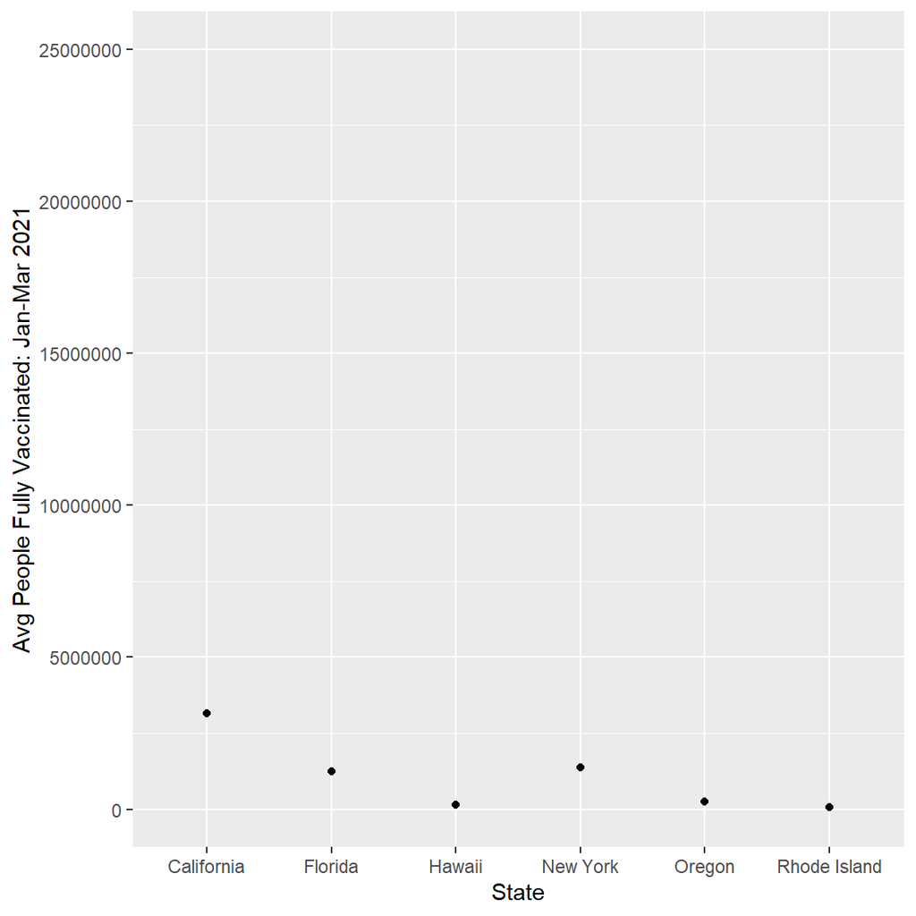

```r
#Plots showing the vaccine progression

#plot showing vaccines (Jan, Feb, Mar)
 ggplot(Data = State.Deaths_Mean.JFM) +
  geom_point(aes( x = State.Deaths_Mean.JFM$State, y = State.Deaths_Mean.JFM$Vaccines_Mean_Jan_Feb_Mar)) +
  xlab("State") + ylab("Avg People Fully Vaccinated: Jan-Mar 2021") +
  ylim(0,25000000)
```

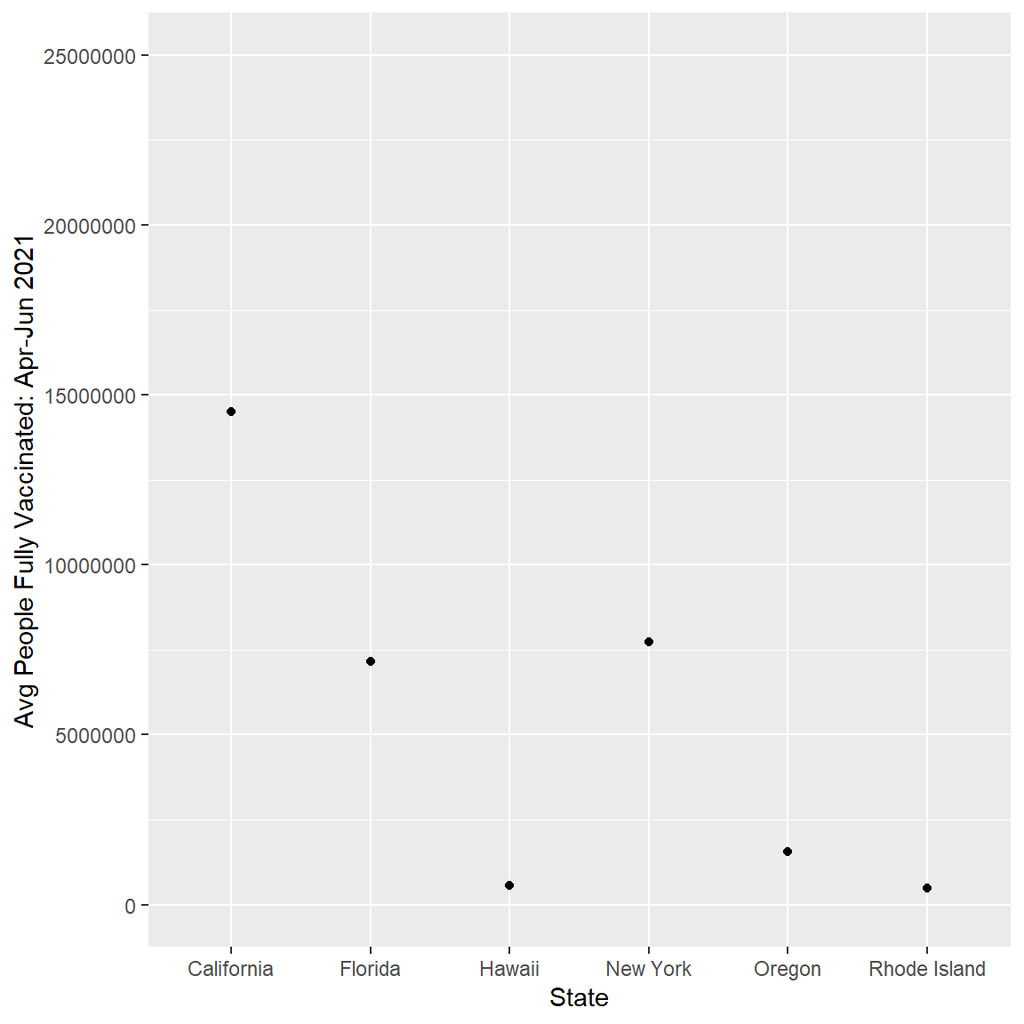

```r
#plot showing vaccines (Apr, May, Jun)
 ggplot(Data = State.Deaths_Mean.AMJ) +
  geom_point(aes( x = State.Deaths_Mean.AMJ$State, y = State.Deaths_Mean.AMJ$Vaccines_Mean_Apr_May_Jun)) +
  xlab("State") + ylab("Avg People Fully Vaccinated: Apr-Jun 2021") +
   ylim(0,25000000)
```

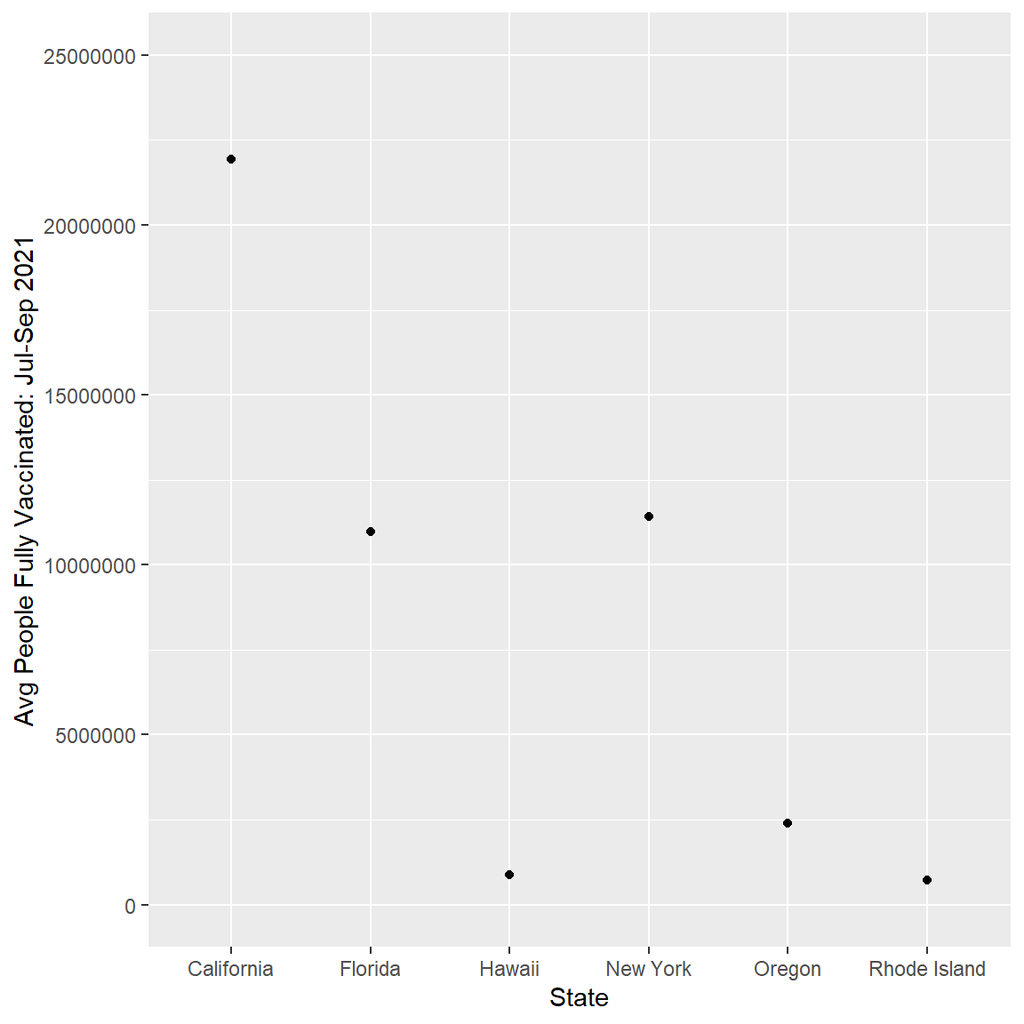

```r
 #plot showing vaccines (Jul, Aug, Sep)
 ggplot(Data = State.Deaths_Mean.JAS) +
  geom_point(aes( x = State.Deaths_Mean.JAS$State, y = State.Deaths_Mean.JAS$Vaccines_Mean_Jul_Aug_Sep)) +
  xlab("State") + ylab("Avg People Fully Vaccinated: Jul-Sep 2021") +
   ylim(0,25000000)
```

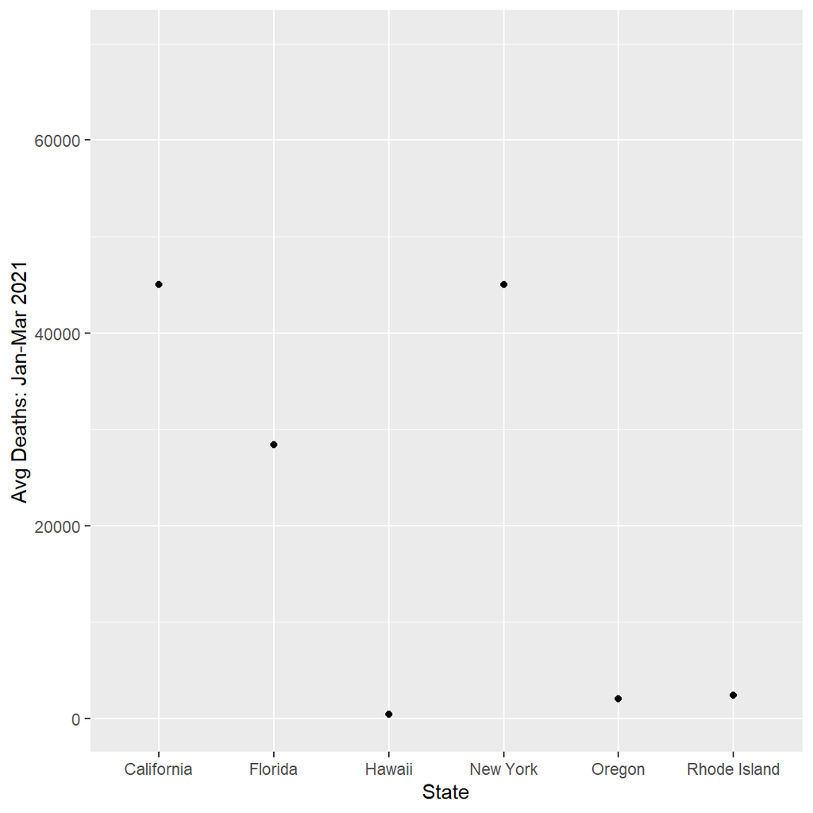

```r
#Plots showing the deaths progression

#plot showing deaths (Jan, Feb, Mar)
 ggplot(Data = State.Deaths_Mean.JFM) +
  geom_point(aes( x = State.Deaths_Mean.JFM$State, y = State.Deaths_Mean.JFM$Deaths_Mean_Jan_Feb_Mar)) +
  xlab("State") + ylab("Avg Deaths: Jan-Mar 2021") +
  ylim(0,70000)
```

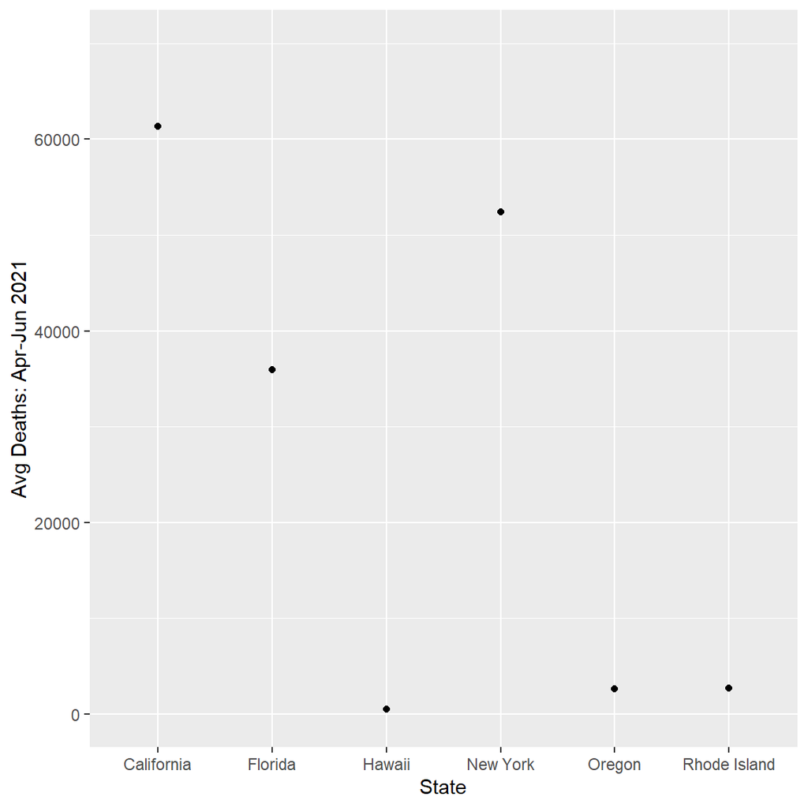

```r
#plot showing deaths (Apr, May, Jun)
 ggplot(Data = State.Deaths_Mean.AMJ) +
  geom_point(aes( x = State.Deaths_Mean.AMJ$State, y = State.Deaths_Mean.AMJ$Deaths_Mean_Apr_May_Jun)) +
  xlab("State") + ylab("Avg Deaths: Apr-Jun 2021") +
   ylim(0,70000)
```

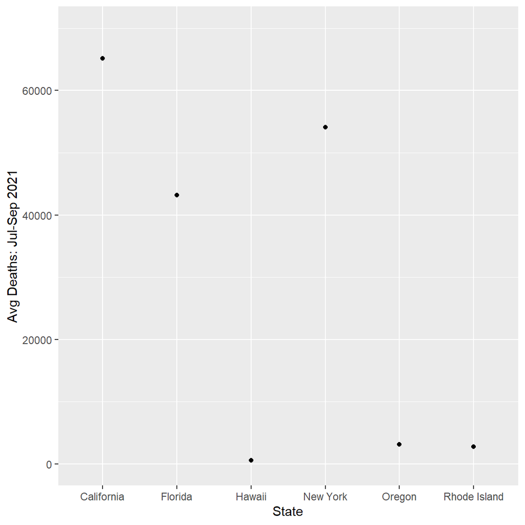

```r
 #plot showing deaths (Jul, Aug, Sep)
 ggplot(Data = State.Deaths_Mean.JAS) +
  geom_point(aes( x = State.Deaths_Mean.JAS$State, y = State.Deaths_Mean.JAS$Deaths_Mean_Jul_Aug_Sep)) +
  xlab("State") + ylab("Avg Deaths: Jul-Sep 2021") +
   ylim(0,70000)
```

5. Choose two of your six states. Load their corresponding policy tracker data sets and use the relevant functions in the `stringr` package to extract policies related to any one of `vaccination`, `mask` or `distancing`.

```r
#California policies
policytrackerCA_vec <- pull(policytrackerCA, policy)

print("CALIFORNIA Policies related to vaccines")
```

```
## [1] "CALIFORNIA Policies related to vaccines"
```

```r
str_subset(policytrackerCA_vec, "vacc")
```

```
##  [1] "Governor Newsom named Scientific Safety Review Workgroup to advise state on COVID-19 vaccines  "
##  [2] "California Department of Public Health named drafting guidelines workgroup to advise state on COVID-19 vaccines"
##  [3] "Western States joined California’s Scientific Safety Review Workgroup to ensure safety of COVID-19 vaccine  "
##  [4] "Governor Newsom today announced that California has opted in to the federal COVID-19 Pharmacy Partnership. At no cost to the state or local government, CVS and Walgreens will administer the Pfizer vaccine to residents and staff in long-term care facilities."
##  [5] "California State Epidemiologist Dr. Erica S. Pan issued the following statement today recommending providers pause the administration of lot 41L20A of the Moderna COVID-19 vaccine due to possible allergic reactions that are under investigation."
##  [6] "Governor Gavin Newsom today announced a series of improvements to the state’s vaccination plan. Incorporating lessons learned from efforts to increase the pace of vaccination, these new steps will make it easier for people to know when they are eligible for vaccination and how to make an ap…
##  [7] "California Governor Gavin Newsom and the Biden-Harris Administration today announced a pilot project to establish community vaccination sites in Oakland and Los Angeles. These pilot sites, which will be based at the Oakland-Alameda Coliseum and California State University, Los Angeles, are …
##  [8] "State Outlines Equity-Centered Plan to Accelerate Access to COVID Vaccines for Education Workers. State has dedicated a minimum of 10 percent of vaccine supply to K-12 school staff and child care workers, or an estimated 75,000 vaccines per week. Plan will build on county and local efforts …
##  [9] "California Department of Public Health (CDPH) announced a new public education campaign under its Vaccinate ALL 58 effort to ramp up the connections being made with Californians who have been disproportionately affected by COVID-19 and address questions and concerns they have with the vacci…
## [10] "Governor Gavin Newsom today outlined the state’s next step in the COVID-19 pandemic recovery, moving beyond the Blueprint for a Safer Economy.On June 15, California will fully open its economy if two criteria are met: If vaccine supply is sufficient for Californians 16 years and older who w…
## [11] "Governor Newsom Announces New Resource to Make COVID-19 Vaccinations More Convenient for Working Californians. Governor Gavin Newsom  announced the state’s new Employer Vaccination Toolkit, which will ease the process for employers to request a workplace clinic or local provider partner, ma…
## [12] "California Department of Public Health (CDPH) issued a new public health order requiring all school staff to either show proof of full vaccination or be tested at least once per week."
## [13] "California becomes the first state to announce plans to require student vaccinations – adding the COVID-19 vaccine to list of vaccinations required for school, such as the vaccines for measles, mumps, and rubella"
## [14] "Governor Newsom Signs Order to Update Workplace Safety Rules. In California, starting March 1, masks will no longer be required for unvaccinated workers indoors, consistent with the updated CDPH guidance, but will be strongly recommended for all individuals in most indoor settings. Employer…
```

```r
print("CALIFORNIA Policies related to masks")
```

```
## [1] "CALIFORNIA Policies related to masks"
```

```r
str_subset(policytrackerCA_vec, "mask")
```

```
## [1] "California's Public Health Department announced that it received federal approval to use some of its emergency planning reserves of 21 million N95 filtering facepiece masks in certain low-risk situations to relieve pressure on the supply chain. March 4, 2020 Governor Newsom declared a state …
## [2] "The Governor issued an executive order that will help increase the availability of over-the-counter drugs, such as hand sanitizer, and medical devices, such as respirators, ventilators and masks."
## [3] "Governor Newsom Signs Order to Update Workplace Safety Rules. In California, starting March 1, masks will no longer be required for unvaccinated workers indoors, consistent with the updated CDPH guidance, but will be strongly recommended for all individuals in most indoor settings. Employers…
```

```r
print("CALIFORNIA Policies related to distancing")
```

```
## [1] "CALIFORNIA Policies related to distancing"
```

```r
str_subset(policytrackerCA_vec, "distanc")
```

```
## [1] "The Governor issued an executive order ensuring California public school districts retain state funding even in the event of physical closure. The order directs school districts to use those state dollars to fund distance learning and high-quality educational opportunities, provide school me…
## [2] "The Governor announced an agreement between teachers, classified employees, school boards, superintendents, and principals to work together to provide distance learning to students as a result of school closures."
## [3] "The California Public Utilities Commission announced $30 million in funding to help school districts ensure that families have Internet access and computing devices for distance learning."
## [4] "The Governor issued an executive order requiring local education agencies, including school districts, to publish a written report to their communities explaining how they have responded to COVID-19, including steps taken to deliver distance learning and meet the needs of disadvantaged stude…
## [5] "The Governor ordered all beaches and state parks in Orange County to temporarily close on April 30, after violations of the states physical distancing rules."
## [6] "The Governor issued an executive order that temporarily broadens the capability of counties to enroll persons into the California Work Opportunity and Responsibility to Kids (CalWORKs) program using various eligibility verification methods due to social distancing requirements."
## [7] "The Governor issued a mandate requiring residents to wear face coverings in common and public indoor spaces and outdoors when physical distancing is not possible."
```

```r
#Oregon policies
policytrackerOR_vec <- pull(policytrackerOR, policy)

print("OREGON Policies related to vaccines")
```

```
## [1] "OREGON Policies related to vaccines"
```

```r
str_subset(policytrackerOR_vec, "vacc")
```

```
## [1] "The Division of Financial Regulations highlighted three coronavirus scams for Oregonians to avoid: Scams claiming to have top-secret vaccine or miracle cure or claiming to offer government assistance or economic relief; Scams requiring downloads to view coronavirus maps; and Scams using the …
## [2] "Western States joined California’s Scientific Safety Review Workgroup to ensure safety of COVID-19 vaccine"
## [3] "Governor Kate Brown held a press conference today commemorating the administration of the first COVID-19 vaccinations in Oregon to frontline health care workers."
## [4] "Governor Kate Brown directed the Oregon Health Authority (OHA) to achieve the benchmark of 12,000 vaccinations administered in Oregon per day by the end of the next two weeks."
## [5] "Governor Kate Brown Announces all people in Phase 1B, Group 7 will become eligible for vaccination, two weeks earlier than previously planned."
## [6] "Governor Kate Brown announced that she has directed the Oregon Health Authority (OHA) to issue a rule outlining new, required health and safety measures for personnel in health care settings. The rule requires weekly COVID-19 testing for personnel in health care settings to prevent the sprea…
## [7] "Governor Kate Brown announced two new vaccination measures to address Oregon’s hospital crisis, caused by the Delta variant surge, and to help keep Oregon students safe in the upcoming school year and minimize disruptions to in-person instruction: 1) Oregon’s vaccination requirement for heal…
```

```r
print("OREGON Policies related to masks")
```

```
## [1] "OREGON Policies related to masks"
```

```r
str_subset(policytrackerOR_vec, "mask")
```

```
## [1] "The Governor received 78 pallets of personal protective equipment (PPE) from the U.S. Agency for International Development (USAID), replenishing the states stockpiles of critically needed N95 masks and other PPE."
## [2] "Oregon will be adopting new indoor mask policies and moving from mask requirements to mask recommendations in schools."
```

```r
print("OREGON Policies related to distancing")
```

```
## [1] "OREGON Policies related to distancing"
```

```r
str_subset(policytrackerOR_vec, "distanc")
```

```
## [1] "The Governor announced new statewide actions for The next four weeks regarding social distancing to reduce The spread of COVID-19"
## [2] "The Governor announced a regional partnership with California Governor Gavin Newsom and Washington Governor Jay Inslee to create a shared vision for reopening their economies and harmonize lifting social distancing measures. The Governors have centered on four overarching goals: Protect vuln…
## [3] "The Oregon Department of Consumer and Business Services issued an emergency order for health insurance companies, requiring them to:Provide at least a 60-day grace period to pay any past due premiums; Pay claims for any covered services during the first 30 days of the grace period; and, Exte…
## [4] "The Governor announced new enforcement measures on face covering, physical distancing, and occupancy standards for businesses over the Fourth of July holiday weekend and thereafter."
## [5] "The Governor released metrics to guide school district decisions about when it is safe to resume in-person instruction, and when a transition to comprehensive distance learning is necessary."
## [6] "Oregon OSHA is proposing a permanent rule that largely maintains – with some improvements – the risk-reducing measures required by the current temporary emergency rule. It would replace the temporary rule, which expires on May 4. the proposed permanent rule maintains such requirements as phy…
```

6. Get Creative: formulate and explore ONE question about the 3 highly and 3 mildly affected states with any of the data sets I have provided.

My Question: Which state out of California, Florida, New York, Hawaii, Oregon, and Rhode Island has the biggest case fatality ratio?

```r
#filtering and selecting California, Florida, New York, Hawaii, Oregon, and Rhode Island and the case fatality ratio
case.fatality.ratio <- covid.usa.daily %>% filter(Province_State == "California" | Province_State == "Florida" | Province_State == "New York" | Province_State == "Hawaii" | Province_State == "Oregon" | Province_State == "Rhode Island") %>% select(Province_State, Case_Fatality_Ratio)
case.fatality.ratio
```

```
## # A tibble: 6 x 2
##   Province_State Case_Fatality_Ratio
##   <chr>                        <dbl>
## 1 California                   0.962
## 2 Florida                      1.22
## 3 Hawaii                       0.544
## 4 New York                     1.28
## 5 Oregon                       1.01
## 6 Rhode Island                 0.917
```

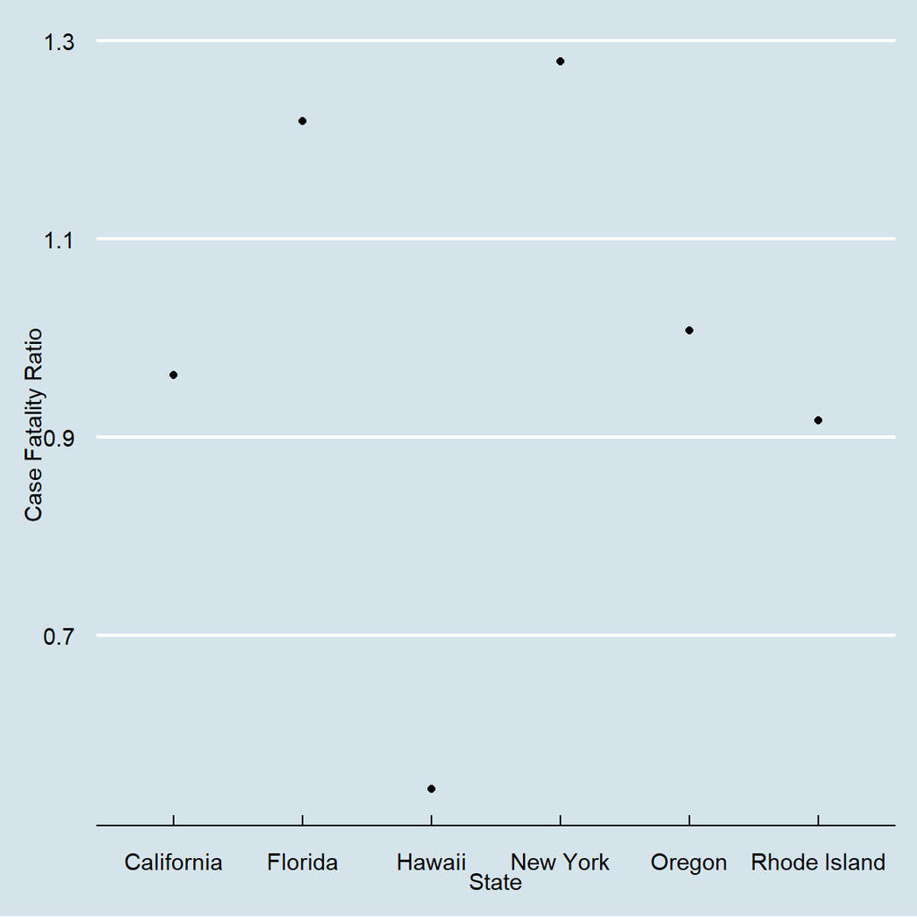

```r
#plot
case.fatality.ratio.plot <- ggplot(case.fatality.ratio, aes(x = Province_State, y = Case_Fatality_Ratio)) +
  geom_point() +
  xlab("State") +
  ylab("Case Fatality Ratio") +
  theme_economist()
case.fatality.ratio.plot
```

The answer to my question is New York.

Phewww… **have fun and GOOD LUCK**!!